# Py: NumPy

Py: NumPy

introduction à NumPy et MatPlotLib

## Directory

# CheatSheet

# numpy

## Importer numpy

- par convention `numpy` est utilisé via l'alias `np`
- cela permet de prefixer les fonctions de la librairie en utilisant `np.` à la place de `numpy.`

```python
import numpy as np
```

## Arrays

- les **Arrays** représentent une collection de valeurs

**contrairement aux listes:**

- les arrays ont une *taille fixe*
  - elles peuvent être resize mais cela implique la recopie de l'array
- toutes les valeurs ont le *même type*
  - typiquement des floats

**tout comme les listes:**

- les arrays sont *mutables*
- on peut changer les éléments d'un array

## Arrays de numpy

- les array sont fourni par le module `numpy`
- la fonction `array()` crée et arrange une liste donnée

```python
import numpy as np

x = np.array([0, 1, 2, 3, 4])
x
```

```
array([0, 1, 2, 3, 4])
```

## Affichage

- la fonction `print()` nous donne un *pretty display*

```python
print(x)
```

```
[0 1 2 3 4]
```

- l'utilisation du nom de la variable (dans la console uniquement) nous donne un affichage qui nous permet de différencier les array des *listes* classiques

```python
x
```

```
array([0, 1, 2, 3, 4])
```

## Indexe

- on peut utiliser les indexes de la même façon que pour une liste

```python
x[4]
```

```
4
```

```python
x[4] = 2
x
```

```
array([0, 1, 2, 3, 2])
```

## Les arrays ne sont pas des listes

- même si ça y ressemble, les array sont une structure de donnée fondamentalement différente:

```python
type(x)
```

```
numpy.ndarray
```

- par exemple, on ne peut pas utiliser des methodes comme `append()`

```python
x.append(5)
```

```
---------------------------------------------------------------------------
AttributeError                            Traceback (most recent call last)
<ipython-input-8-2f1e4fff5cec> in <module>()
----> 1 x.append(5)

AttributeError: 'numpy.ndarray' object has no attribute 'append'
```

## Utilisation de fonctions sur des Arrays

- Si on utilise des opérateurs arithmétiques sur des arrays, on crée un nouvel array auquel, sur chaque élément, a été appliqué l'opérateur

```python
y = x * 2
y
```

```
array([0, 2, 4, 6, 4])
```

- même chose pour les fonctions

```python
x = np.array([-1, 2, 3, -4])
y = abs(x)
y
```

```
array([1, 2, 3, 4])
```

## peupler les Array

- pour peupler un array avec un range de valeurs, on utilise la fonction `np.arange()`

```python
x = np.arange(0,10)
print(x)
```

```
[0 1 2 3 4 5 6 7 8 9]
```

- on peut utiliser une incrémentation *float*

```python
x = np.arange(0,1,0.1)
print(x)
```

```
[ 0.   0.1  0.2  0.3  0.4  0.5  0.6  0.7  0.8  0.9]
```

```python
x
```

```
array([ 0. ,  0.1,  0.2,  0.3,  0.4,  0.5,  0.6,  0.7,  0.8,  0.9])
```

## Vectorisation de fonctions

- **toutes** les fonctions **ne fonctionnent pas automatiquement** avec les arrays
- les fonctions qui fonctionnes avec les arrays sont dites **vectorisées**
- la majorité des fonctions de `numpy` sont vectorisées
- on peut définir des fonctions vectorisées nous même (un peu comme la surcharge en C++) grâce a la fonction *supérieure* `numpy.vectorize()`

```python
def myfunc(x):
    if x >= 0.5:
        return x
    else:
        return 0.0

fv = np.vectorize(myfunc)
```

```python
x = np.arange(0, 1, 0.1)
x
```

```
array([ 0. ,  0.1,  0.2,  0.3,  0.4,  0.5,  0.6,  0.7,  0.8,  0.9])
```

```python
fv(x)
```

```
array([ 0. ,  0. ,  0. ,  0. ,  0. ,  0.5,  0.6,  0.7,  0.8,  0.9])
```

## Plot de base

- on utilise le module `matplotlib` pour ploter des graphs
- ce module fait partie de `pyplot`
- par convention nous importons `matplotlib` via l'alias `plt`
- ce module apporte des fonctions très similaires à celles de [MATLAB](http://ch.mathworks.com/help/matlab/ref/plot.html?requestedDomain=uk.mathworks.com)

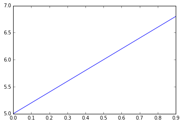

```python
import matplotlib.pyplot as plt
# uniquement nécéssaire pour Jupyter
%matplotlib inline

y = x*2 + 5
plt.plot(x, y)
```

## Plot d'une sin

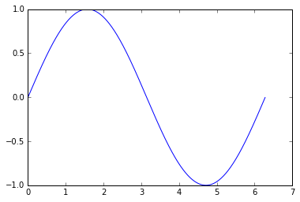

```python
from numpy import pi, sin

x = np.arange(0, 2*pi, 0.01)
y = sin(x)
plt.plot(x, y)
```

## Données multidimensionnelles

- les arrays de numpy peuvent contenir des données multidimensionnelles
- pour créér un array multidimensionnel, nous pouvons passer une liste de listes à la fonction `array()`

```python
import numpy as np

x = np.array([[1, 2], [3, 4]])
x
```

```
array([[1, 2],
       [3, 4]])
```

## Array d'arrays

- un array multidimensionnel est un array d'array
- l'array extérieur contient les lignes
- chaque ligne est un array

```python
x[0]
```

```
array([1, 2])
```

```python
x[1]
```

```
array([3, 4])
```

- l'élément dans la seconde ligne et première colonne est:

```python
x[1][0]
```

```
3
```

## Matrices

- nous pouvons transformer un array multidimensionnel en *matrice*

```python
M = np.matrix(x)
M
```

```
matrix([[1, 2],
        [3, 4]])
```

## Plot multidimensionnel avec des matrices

- si nous utilisons `plot()` pour ploter une *matrice*, ce dernier utilisera les valeurs de l'axe des *y* (colones de la matrice).

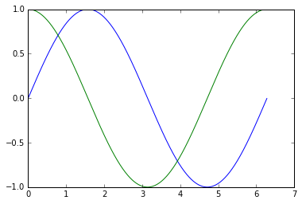

```python
from numpy import pi, sin, cos

x = np.arange(0, 2*pi, 0.01)
y = sin(x)
ax = plt.plot(x, np.matrix([sin(x), cos(x)]).T)
```

## Performance

- les matrices de `numpy` sont liées à des fonctions correspondantes écritent en **C** et **FORTRAN**
- Ces librairies sont très rapides et peuvent être configurées de façon à ce que les opérations soient faites en parallèle sur plusieurs coeurs.

## Opérations sur les matrices

- Une fois que nous avons une matrice nous pouvons lui appliquer des opérations spécifiques à ces dernières
- pour [transposer](https://fr.wikipedia.org/wiki/Matrice_transpos%C3%A9e) et [inverser](https://fr.wikipedia.org/wiki/Matrice_inversible) on utilise respectivement les attributs T et I

```python
import numpy as np

x = np.array([[1, 2], [3, 4]])
M = np.matrix(x)
M
```

```
matrix([[1, 2],
        [3, 4]])
```

Pour effectuer la transposition $M^T$:

```python
M.T
```

```
matrix([[1, 3],
        [2, 4]])
```

Pour effectuer l'inversion $M^{-1}$:

```python
M.I
```

```
matrix([[-2. ,  1. ],
        [ 1.5, -0.5]])
```

## Dimensions d'une matrice

- le nombre total d'éléments et les dimensions de la matrice:

```python
M.size
```

```
4
```

```python
M.shape
```

```
(2, 2)
```

```python
len(M.shape)
```

```
2
```

## Créer une matrice à partir de strings

- nous pouvons aussi créér des matrices directement à partir de strigs:

```python
I2 = np.matrix('2 0; 0 2')
I2
```

```
matrix([[2, 0],
        [0, 2]])
```

- le point virgule (;) marque le début d'une nouvelle ligne

## Multiplication de matrices

- maintenant que nous avons deux matrices, nous pouvons les multiplier:

```python
M * I2
```

```
matrix([[2, 4],
        [6, 8]])
```

## Indexes et matrices

- nous pouvons utiliser les indexes et même slicer une matrices en utilisant la même syntaxe que pour les listes

```python
M[:,1]
```

```
matrix([[2],
        [4]])
```

## Les slices sont des références

- de la façon suivante, on crée une *référence* à l'élément slicé et **non pas une copie**

```python
V = M[:,1] # ne crée pas une copie des éléments mais référence l'objet initial !
V
```

```
matrix([[2],
        [4]])
```

```python
M[0,1] = -2
V
```

```
matrix([[-2],
        [ 4]])
```

## Copier des matrices et des vecteurs

- pour copier une matrice ou une slice de ses éléments, on utilise la fonction `np.copy()`

```python
M = np.matrix('1 2; 3 4')
V = np.copy(M[:,1]) # copie des éléments
V
```

```
array([[2],
       [4]])
```

```python
M[0,1] = -2
V
```

```
array([[2],
       [4]])
```

## Somme

- une façon de faire la sommer un vecteur ou une matrice est via une boucle `for`

```python
vector = np.arange(0.0, 100.0, 10.0)
vector
```

```
array([  0.,  10.,  20.,  30.,  40.,  50.,  60.,  70.,  80.,  90.])
```

```python
result = 0.0
for x in vector:
    result += x

result
```

```
450.0
```

- **ce n'est pas une façon éfficace d'effectuer une somme**

## Somme efficace

- à la place de la boucle `for` nous pouvons utiliser la fonction `sum()`
- cette fonction est écrite en **C** et est beaucoup plus performante

```python
vector = np.array([0, 1, 2, 3, 4])
print(np.sum(vector))
```

```
10
```

## Somme des lignes / colones

- quand nous avons affaire à des données multidimensionnelles, la fonction `sum()` possède un argument *axis* qui ne permet de spécifier si nous désirons la somme des lignes ou des colonnes

```python
matrix = np.matrix('1 2 3; 4 5 6; 7 8 9')
print(matrix)
```

```
[[1 2 3]
 [4 5 6]
 [7 8 9]]
```

- somme des lignes

```python
np.sum(matrix, axis=0)
```

```
matrix([[12, 15, 18]])
```

- somme des colonnes

```python
np.sum(matrix, axis=1)
```

```
matrix([[ 6],
        [15],
        [24]])
```

## Sommes cumulatives

```python
x = np.matrix('1 2 3; 4 5 6; 7 8 9')
print(x)
```

```
[[1 2 3]
 [4 5 6]
 [7 8 9]]
```

```python
y = np.cumsum(x)
print(np.cumsum(x, axis=0))
```

```
[[ 1  2  3]
 [ 5  7  9]
 [12 15 18]]
```

```python
print(np.cumsum(x, axis=1))
```

```
[[ 1  3  6]
 [ 4  9 15]
 [ 7 15 24]]
```

## Produit cumulé

- de façon similaire, nous pouvons calculer $\large{y_n = \Pi^{n}_{i-1}{x_i}}$ en utilisant `cumprod()`

```python
import numpy as np
x = np.array([1, 2, 3, 4, 5])
print(np.cumprod(x))
```

```
[  1   2   6  24 120]
```

- nous pouvons calculer le produit cummulatif entre les lignes et les colonnes en utilisant le paramètre *axis*.

## Génération de nombres pseudo aléatoires

- le sous module `numpy.random` contient des fonctions pour générer des nombres aléatoires

```python
from numpy.random import normal, uniform, exponential, randint
```

- supposons que nous avons une variable aléatoire $\large{\epsilon \sim N(0,1)}$
- dans Python nous pouvons utiliser cette distribution de la façon suivante:

```python
epsilon = normal()
print(epsilon)
```

```
-1.2582109218484931
```

- chaque appel de cette variable nous retournera la même valeur

```python
print(epsilon)
```

```
-1.2582109218484931
```

- si nous appellons encore une fois la fonction, celà va nous retourner un nouveau draw de cette distribution:

```python
epsilon = normal()
print(epsilon)
```

```
-0.6266440554602674
```

## Nombres pseudo-aléatoires

- en réalité ces nombres ne sont pas des nombres aléatoires
- ils sont basés sur un état initial appelé *seed*
- si nous connaissons le *seed*, nous pouvons prédire précisément le reste de la séquence à partir de n'importe quel nombre "aléatoire".
- cela dit, statistiquement parlant ces nombres se comportent comme des nombres aléatoires

## Gestion des *seed*

- dans certains cas nous avons besoin de pouvoir reproduir une séquence de nombres pseudo aléatoires
- nous pouvons spécifier la valeur du *seed* avant utilisation de ces nombres
- pour se faire on utilise la fonction `seed()` dans le sous module `numpy.random`

```python
from numpy.random import seed

seed(5)
```

```python
normal()
```

```
0.44122748688504143
```

```python
normal()
```

```
-0.33087015189408764
```

```python
seed(5)
```

```python
normal()
```

```
0.44122748688504143
```

```python
normal()
```

```
-0.33087015189408764
```

## Générer multiple

- pour se faire nous pouvons spécifier le paramétre `size`:

```python
normal(size=10)
```

```
array([ 2.43077119, -0.25209213,  0.10960984,  1.58248112, -0.9092324 ,
       -0.59163666,  0.18760323, -0.32986996, -1.19276461, -0.20487651])
```

**Cette façon de procéder est BEAUCOUP plus rapide qu'une boucle for!**

- nous pouvons également spécifier plus d'une dimension:

```python
normal(size=(5,5))
```

```
array([[-0.35882895,  0.6034716 , -1.66478853, -0.70017904,  1.15139101],
       [ 1.85733101, -1.51117956,  0.64484751, -0.98060789, -0.85685315],
       [-0.87187918, -0.42250793,  0.99643983,  0.71242127,  0.05914424],
       [-0.36331088,  0.00328884, -0.10593044,  0.79305332, -0.63157163],
       [-0.00619491, -0.10106761, -0.05230815,  0.24921766,  0.19766009]])
```

## Histogrammes

- pour ploter un histogramme de données distribuées aléatoirement, on utilise la fonction `hist()` de `mtplotlib`:

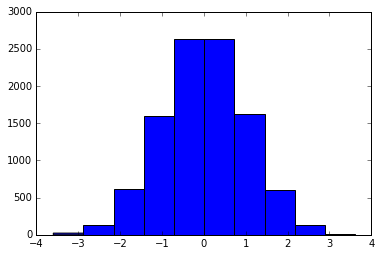

```python
import matplotlib.pyplot as plt
%matplotlib inline

data = normal(size=10000)
ax = plt.hist(data)
```

## Calculer les histogrammes en matrices

```python
import numpy as np
np.histogram(data)
```

```
(array([  23,  136,  618, 1597, 2626, 2635, 1620,  599,  130,   16], dtype=int64),
 array([-3.59780883, -2.87679609, -2.15578336, -1.43477063, -0.71375789,
         0.00725484,  0.72826758,  1.44928031,  2.17029304,  2.89130578,
         3.61231851]))
```

## Statistiques

- nous pouvons calculer les statistiques d'un sample de données en utilisant les fonctions de `numpy` `mean()` et `var()`

```python
np.mean(data)
```

```
-0.00045461080333497925
```

```python
np.var(data)
```

```
1.0016048722546331
```

- ces fonctions ont aussi un paramètre `axis` pour calculer la moyenne d'arrays multidimensionnels.

## Nombres aléatoires discrets

- la fonction `randint()` du module `numpy.random` peut être utilisé pour sortir des nombres aléatoires
- il prend deux paramètres: valeur basse (inclus), et valeur haute (exclue)
- pour simuler un jet de dé:

```python
die_roll = randint(0,6)+1
die_roll
```

```
4
```

# Résumé

# Numpy

[doc numpy](https://docs.scipy.org/doc/numpy/reference/index.html)

Numpy est une librairie centrale pour le calcule scientifique en Python. Elle contient **une collection d'outils** qui permettent de résoudre et de modéliser des problèmes mathématiques, scientifiques et du domaine de l'ingénierie.

Le **coeur** de ces outils est une structure de données de type **liste multidimentionnelle** de haut performance qui se nome tout simplement **Array** (Numpy Array).

- Voici un exemple d'un array 2d dans Numpy:

```python
import numpy

M = numpy.array([[1,2,3], [4,5,6]])
M
```

```
array([[1, 2, 3],
       [4, 5, 6]])
```

## Performance

- les matrices de `numpy` sont liées à des fonctions correspondantes écritent en **C** et **FORTRAN**
- Ces librairies sont très rapides et peuvent être configurées de façon à ce que les opérations soient faites en parallèle sur plusieurs coeurs.

## Dimensions

Cette illustration représente les 3 premières dimensions de l'objet mathématique *matrice*

- axis 0 (idx[0]) axe des $\large x$
- axis 1 (idx[0][0]) axe des $\large y$
- axis 2 (idx[0][0][0]) axe des $\large z$

[figure not shown]

Et voici la représentation de matrices comme nous le `print()` Numpy

- matrice à une dimension:

[1,1,1]

- matrice à deux dimensions:

[[[1 1 1] [1 1 1] [1 1 1]]

- matrice à trois dimensions:

[[[1 1 1] [1 1 1] [1 1 1]] [[1 1 1] [1 1 1] [1 1 1]] [[1 1 1] [1 1 1] [1 1 1]]]

## Arrays

- les Arrays représentent une **collection de données**

**contrairement aux listes:**

- les arrays ont une **taille fixe**
  - elles peuvent être resize mais cela implique la recopie de l'array
- c'est une collection **homogène** (toutes les données ont le *même type*)
  - typiquement des floats

**tout comme les listes:**

- les arrays sont **mutables** (on peut changer les éléments d'un array)

Numpy permet de créer plusieurs types d'arrays. On appelle:

- **vecteur** un array 1d
- **matrice** un array multi d. (fondamentalement c'est un vecteur aussi)

L'implémentation des Numpy Arrays possède **4 pointeurs importants**:

- **data** pointe sur l'adresse du premier byte de l'array
- **dtype** pointe sur une représentation du type de donnès que contient la collection
- **shape** pointe sur une représentation de la forme de l'array (tuple dont le nombre d'éléments représente le nombre de dimensions et la clé des éléments la taille de cette dimension)
- **strides** pointe sur une représentation du nombre de bytes qui doivent être sauté en mémoire pour arriver au prochain élément. Si l'objet retourné est par exemple (10,1) ont doit sauter 1 byte pour passer à la colonne suivante et 10 bytes pour sauter à la ligne suivante.

En somme, un array contient des informations concernant les `raw data` (données en elles mêmes) mais aussi sur comment interpréter ces données.

```python
print("représentation:  \n",    M,"\n")
print("pointeur data:   \t",    M.data)
print("pointeur type:   \t",    M.shape)
print("pointeur shape:  \t",   M.dtype)
print("pointeur strides:\t", M.strides)
```

```
représentation:
 [[1 2 3]
 [4 5 6]]

pointeur data:   	 <memory at 0x0000025C90B9B048>
pointeur type:   	 (2, 3)
pointeur shape:  	 int32
pointeur strides:	 (12, 4)
```

Les arrays possèdent des methodes qui nous permettent d'inspecter notre array voici celles qui peuvent être uttile à ce niveau:

- **.ndim** retourne le nombre de dimensions

```python
print(M.ndim)
```

```
2
```

- **.size** retourne le nombre d'éléments

```python
print(M.size)
```

```
6
```

- **.flags** retourne des informations utiles sur la gestion de la mémoire

```python
print(M.flags)
```

```
  C_CONTIGUOUS : True
  F_CONTIGUOUS : False
  OWNDATA : True
  WRITEABLE : True
  ALIGNED : True
  UPDATEIFCOPY : False
```

- **.itemize** retourne le poids d'un élément de l'array en bytes

```python
print(M.itemsize)
```

```
4
```

- **.nbytes** retourne le poids total en bytes de l'array

```python
print(M.nbytes)
```

```
24
```

## Création d'arrays

- par convention `numpy` est utilisé via l'alias `np`
- cela permet de prefixer les fonctions de la librairie en utilisant `np.` à la place de `numpy.`

```python
import numpy as np
```

### Creation d'array 1d

- conversion de listes classiques en array

```python
a = [1,3,5,7,9]

print(type(a))
print(a)
```

```
<class 'list'>
[1, 3, 5, 7, 9]
```

```python
b = np.array(a)

print(type(b))
print(b)
```

```
<class 'numpy.ndarray'>
[1 3 5 7 9]
```

- création directe d'array

```python
a = np.array([1,3,5,7,9], dtype=np.int64)

print(a)
print(a.dtype)
```

```
[1 3 5 7 9]
int64
```

- il n'est pas obligatoire de spécifier le type de données par défaut ce sont des *int32*

```python
b = np.array([1,3,5,7,9])

print(b)
print(b.dtype)
```

```
[1 3 5 7 9]
int32
```

### Création de matrices (multi d.)

- conversion de liste 2d en matrice

```python
l = [[1,2,3], [4,5,6], [7,8,9]]
A = np.array(l)

print(A)
```

```
[[1 2 3]
 [4 5 6]
 [7 8 9]]
```

- création directe de matrice

```python
B = np.array([[1,2,3], [4,5,6], [7,8,9]])

print(B)
```

```
[[1 2 3]
 [4 5 6]
 [7 8 9]]
```

### Création d'array "vides" et peuplement d'array

Parfois on ne sait pas d'avance la valeurs des données que contiendra notre array où ces données seront importé d'une autre source. Dans ce cas on initialisera l'array respectivement avec des des *placeholders* "vides" ou nous utiliserons des fonctions pour charger les données à partir de fichiers textes. Un array vide est un array qui ne contient que des $1$ ou des $0$ qui sont les *placeholders* qui seront remplis par la suite.

#### ones(shape, dtype=None)

- matrice 2d remplie de $1$ (si nous ne spécifions pas le type, par défaut la methode `ones` initialise avec des floats64)

```python
a = np.ones((3,4))

print(a)
print(a.dtype)
```

```
[[ 1.  1.  1.  1.]
 [ 1.  1.  1.  1.]
 [ 1.  1.  1.  1.]]
float64
```

```python
a = np.ones((3,4), dtype=np.int32)

print(a)
print(a.dtype)
```

```
[[1 1 1 1]
 [1 1 1 1]
 [1 1 1 1]]
int32
```

#### zeros(shape, dtype=float)

- matrice 3d de 0

```python
b = np.zeros((2,3,4), dtype=np.int32)

print(b)
```

```
[[[0 0 0 0]
  [0 0 0 0]
  [0 0 0 0]]

 [[0 0 0 0]
  [0 0 0 0]
  [0 0 0 0]]]
```

#### empty(shape, dtype=float)

- matrice 2d "vide" d'un certain type (par défaut float64)

```python
c = np.empty((3,2), dtype=np.int32)

print(c)
print(c.dtype)
```

```
[[0 0]
 [0 0]
 [0 0]]
int32
```

#### random(shape)

- matrice 2d remplie avec des valeurs aléaoires (**pas de paramètre dtype**)

```python
d = np.random.random((3,2))

print(d)
print(d.dtype)
```

```
[[ 0.09215501  0.01565501]
 [ 0.20720279  0.92122324]
 [ 0.71029601  0.11913718]]
float64
```

- matrice 2d remplie avec des valeurs aléatoires dans un range

```python
d = np.random.uniform(low=0, high=30, size=(3,2))

print(d)
```

```
[[ 11.19862244  22.98332516]
 [ 14.15014321  19.59095938]
 [  4.04744523   5.37088694]]
```

- matrice 2d remplie avec des valeurs aléatoires (int) dans un range

```python
d = np.random.randint(30, size=(4,2)).astype(np.int16)
print(d)
```

```
[[ 6  8]
 [ 1  9]
 [ 8 14]
 [19  6]]
```

#### full(shape, fill_value, dtype=None)

- matrice 3d remplie avec une valeur spécifique (**warning si on ne spécifie pas de dtype**)

```python
e = np.full((3,2,3),5, dtype=np.int32)

print(e)
print(e.dtype)
```

```
[[[5 5 5]
  [5 5 5]]

 [[5 5 5]
  [5 5 5]]

 [[5 5 5]
  [5 5 5]]]
int32
```

#### arange(start=None, stop, step=None, dtype=None)

- array 1d de valeurs espacées uniformément

```python
f = np.arange(10,25,5)

print(f)
print(f.dtype)
```

```
[10 15 20]
int32
```

- incrémentation à virgule flotante

```python
f = np.arange(0,1,0.1)

print(f)
print(f.dtype)
```

```
[ 0.   0.1  0.2  0.3  0.4  0.5  0.6  0.7  0.8  0.9]
float64
```

#### linspace(start, stop, endpoint=True, retstep=False, dtype=None)

- array 1d de valeurs espacées uniformément

```python
g = np.linspace(0,2,9)

print(g)
print(g.dtype)
```

```
[ 0.    0.25  0.5   0.75  1.    1.25  1.5   1.75  2.  ]
float64
```

`arange()` et `linspace()` nous permettent de peupler des arrays avec des valeurs espacées uniformément. La différence entre les deux est la signification du 3e paramètre passé en argument.

- `arange()`: c'est le **step** qui désigne l'écart entre deux valeurs
- `linspace()` c'est le nombre de samples:

```python
for i in range(7,0,-1):
    print(np.linspace(0, 5, i, dtype=np.int32))
```

```
[0 0 1 2 3 4 5]
[0 1 2 3 4 5]
[0 1 2 3 5]
[0 1 3 5]
[0 2 5]
[0 5]
[0]
```

### Création d'array et matrice "identité"

An identity matrix is a square matrix of which all elements in the principal diagonal are ones and all other elements are zeros. When you multiply a matrix with an identity matrix, the given matrix is left unchanged.

In other words, if you multiply a matrix by an identity matrix, the resulting product will be the same matrix again by the standard conventions of matrix multiplication.

#### eye(N, M=None, k=0, dtype=float)

- retourne une matrice 2d avec des $1$ sur la diagonale principale et les reste remplis avec des $0$

```python
h = np.eye(3)

print(h)
print(h.dtype)
```

```
[[ 1.  0.  0.]
 [ 0.  1.  0.]
 [ 0.  0.  1.]]
float64
```

#### identity(n, dtype=None)

- retourne une matrice identité carrée (*The identity array is a square array with ones on the main diagonal*)

```python
i = np.identity(4)

print(i)
print(i.dtype)
```

```
[[ 1.  0.  0.  0.]
 [ 0.  1.  0.  0.]
 [ 0.  0.  1.  0.]
 [ 0.  0.  0.  1.]]
float64
```

### Remplir un array avec les valeurs d'un fichier

#### loadtxt()

fichier value.txt

```python
# Value1  Value2  Value3
# 0.2536  0.1008  0.3857
# 0.4839  0.4536  0.3561
# 0.1292  0.6875  0.5929
# 0.1781  0.3049  0.8928
# 0.6253  0.3486  0.8791
```

```python
x, y, z = np.loadtxt('C:/Users/sol.rosca/Jupyter_notbooks/value.txt',
                    skiprows=1,
                    unpack=True)
```

#### genfromtxt()

fichier value2.txt

```python
# Value1  Value2  Value3
# 0.4839  0.4536  0.3561
# 0.1292  0.6875  MISSING
# 0.1781  0.3049  0.8928
# MISSING 0.5801  0.2038
# 0.5993  0.4357  0.7410
```

```python
my_array = np.empty((3,7))
my_array = np.genfromtxt('C:/Users/sol.rosca/Jupyter_notbooks/value2.txt',
                      skip_header=1,
                      filling_values=-999)
```

- `loadtxt()` charge les données dans notre environement.
  - le premier parmètre que prenne les deux fonctions est le path du fichier `value.txt`.
  - ensuite viennent des arguments spécifiques au fonctions.
- pour loadtxt() on passe la première ligne et on retourne les colonnes comme étant des arrays distincts avec l'argument `unpack=TRUE`. Celà veut dire que les valeurs de la première colonne (value1) vont dans la variable `x` etc...

> à noter que si nous avons des valeurs délimitées par des virgules, ou si nous voulons spécifier le type de données, il existe des arguments `delimiter` et `dtype` qu'on peut ajouter à `loadtxt()`
- `genfromtxt()` est utile dans le cas où nous avons à gérer un fichier où il manque des valeurs. Dans le cas présent, les valeurs manquantes sont marquées dans le fichier par string `'MISSING'`. Cette fonction, converti les valeurs par l'argument du paramètre `filing_values` qu'on a ici set à la valeur -999.

Généralement la fonction `genfromtxt()` est plus flexible et plus robuste que `loadtxt()`et offre plus de [possibilités](https://docs.scipy.org/doc/numpy/reference/generated/numpy.genfromtxt.html#numpy.genfromtxt).

```python
M = np.array([x,y,z])
print(M)
```

```
[[ 0.2536  0.4839  0.1292  0.1781  0.6253]
 [ 0.1008  0.4536  0.6875  0.3049  0.3486]
 [ 0.3857  0.3561  0.5929  0.8928  0.8791]]
```

```python
print(my_array)
```

```
[[  4.83900000e-01   4.53600000e-01   3.56100000e-01]
 [  1.29200000e-01   6.87500000e-01  -9.99000000e+02]
 [  1.78100000e-01   3.04900000e-01   8.92800000e-01]
 [ -9.99000000e+02   5.80100000e-01   2.03800000e-01]
 [  5.99300000e-01   4.35700000e-01   7.41000000e-01]]
```

### Sauvegarder des arrays

```python
import numpy as np
x = np.arange(0.0,5.0,1.0)
np.savetxt('test.npy', x, delimiter=',')
```

- `save()` sauvegarde un array au format binaire **npy**
- `savez()` sauvegarde plusieurs arrays au format non compressé **npz**
- `savez_compressed()` sauvegarde plusieurs arrays et les compresse dans un **npz**

[plus d'informations](https://docs.scipy.org/doc/numpy/reference/routines.io.html)

## Vectorisation de fonctions

- **toutes** les fonctions **ne fonctionnent pas automatiquement** avec les arrays
- les fonctions qui fonctionnes avec les arrays sont dites **vectorisées**
- la majorité des fonctions de `numpy` sont vectorisées
- on peut définir des fonctions vectorisées nous même (un peu comme la surcharge en C++) grâce a la fonction *supérieure* `numpy.vectorize()`

```python
def myfunc(x):
    if x >= 0.5:
        return x
    else:
        return 0.0

fv = np.vectorize(myfunc)
```

```python
x = np.arange(0, 1, 0.1)
print(x)
```

```
[ 0.   0.1  0.2  0.3  0.4  0.5  0.6  0.7  0.8  0.9]
```

```python
print(fv(x))
```

```
[ 0.   0.   0.   0.   0.   0.5  0.6  0.7  0.8  0.9]
```

## Plots

- on utilise le module `matplotlib` pour ploter des graphs
- ce module fait partie de `pyplot`
- par convention nous importons `matplotlib` via l'alias `plt`
- ce module apporte des fonctions très similaires à celles de [MATLAB](http://ch.mathworks.com/help/matlab/ref/plot.html?requestedDomain=uk.mathworks.com)

### Plot de base

*dans jupyter plt.show() crash (se renseigner)*

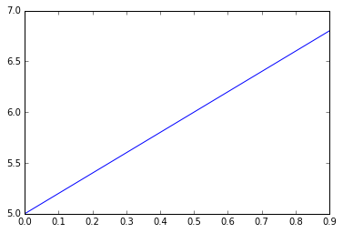

```python
import matplotlib.pyplot as plt
# uniquement nécéssaire pour Jupyter:
%matplotlib inline

x = np.arange(0, 1, 0.1)

y = x*2 + 5
plt.plot(x, y)
```

- en éditeur on rajoute le .show() pour display

### plot d'une sin

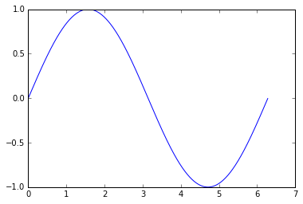

```python
from numpy import pi, sin

x = np.arange(0, 2*pi, 0.01)
y = sin(x)
plt.plot(x, y)
```

### plot de données

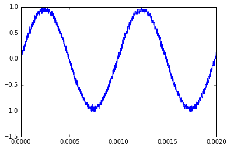

```python
tps, Uch0, Uch1, Ut, It, pT = np.loadtxt('C:/Users/sol.rosca/Jupyter_notbooks/10khz.txt',
                skiprows=0,
                unpack=True)

x = tps
y = Uch0 -Uch1

plt.plot(x,y)
```

## Matrices

```python
import numpy as np

x = np.array([[1, 2], [3, 4]])
x
```

```
array([[1, 2],
       [3, 4]])
```

- nous pouvons transformer un array multidimensionnel en *matrice*
- une matrice est un objet qui permet des opérations différentes que celles qu'on fait sur les arrays

```python
M = np.matrix(x)
M
```

```
matrix([[1, 2],
        [3, 4]])
```

### Créer une matrice à partir de strings

- nous pouvons aussi créér des matrices directement à partir de strigs **ce qui économise des touches**:
- le point virgule (;) marque le début d'une nouvelle ligne

```python
M = np.matrix('2 0; 0 2')
M
```

```
matrix([[2, 0],
        [0, 2]])
```

### Plot multidimensionnel avec des matrices

- si nous utilisons `plot()` pour ploter une *matrice*, ce dernier utilisera les valeurs de l'axe des *y* (colones de la matrice).

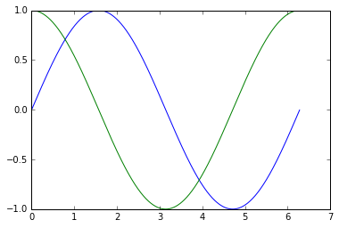

```python
from numpy import pi, sin, cos

x = np.arange(0, 2*pi, 0.01)
y = sin(x)
ax = plt.plot(x, np.matrix([sin(x), cos(x)]).T)
```

## Indexes et slices

Ces opérations sont très similaires aux opérations qu'on peut faire sur les listes.

### Indexes

```python
m = np.random.random((3,3,3))

print(m)
```

```
[[[ 0.63941646  0.81352733  0.90651091]
  [ 0.51359365  0.24843515  0.15306928]
  [ 0.33191867  0.22029804  0.62857814]]

 [[ 0.49583472  0.98747013  0.72117189]
  [ 0.79852925  0.70926013  0.41980934]
  [ 0.11007736  0.47368575  0.07903667]]

 [[ 0.92623158  0.00308526  0.7942609 ]
  [ 0.58085088  0.55688129  0.92179524]
  [ 0.99415609  0.47479977  0.03155755]]]
```

- retourne l'élément à l'indice 1

```python
print(m[1])
```

```
[[ 0.49583472  0.98747013  0.72117189]
 [ 0.79852925  0.70926013  0.41980934]
 [ 0.11007736  0.47368575  0.07903667]]
```

```python
print(m[1][2])
```

```
[ 0.11007736  0.47368575  0.07903667]
```

- même chose syntaxedifférente

```python
print(m[1,2])
```

```
[ 0.11007736  0.47368575  0.07903667]
```

```python
print(m[1,1,2])
```

```
0.419809341929
```

### Slices

- basique:

a[start:end] # items start through the end (but the end is not included!) a[start:] # items start through the rest of the array a[:end] # items from the beginning through the end (but the end is not included!)

```python
n = np.array([[1,2], [3,4]])
print(n)
```

```
[[1 2]
 [3 4]]
```

- accès aux colones:

```python
o = n[:,1]
print(o)
```

```
[2 4]
```

- accès aux lignes:

```python
p = n[:1]
print(p)
```

```
[[1 2]]
```

- même syntaxe pour les matrices:

```python
N = np.matrix('6 7; 8 9')
print(N)
```

```
[[6 7]
 [8 9]]
```

```python
O = N[:,1]
print(O)
```

```
[[7]
 [9]]
```

```python
P = N[:1]
print(P)
```

```
[[6 7]]
```

- **Les slices sont une référence à l'objet initial et non pas une copie**

```python
o[1] = 10
print(n)
```

```
[[ 1  2]
 [ 3 10]]
```

```python
O[1] = 10
print(N)
```

```
[[ 6  7]
 [ 8 10]]
```

## Copier des matrices et des vecteurs

- pour copier une matrice ou une slace de ses éléments, on utilise la fonction `np.copy()`

```python
M = np.matrix('1 2; 3 4')
a = np.copy(M[:,1])

print(a)
```

```
[[2]
 [4]]
```

```python
M[0,1] = -2
print(a)
```

```
[[2]
 [4]]
```

## Somme

- une façon de sommer les éléments d'un array ou d'une matrice est d'utiliser une boucle for

```python
a = np.arange(0.0, 100.0, 10.0)
print(a)
```

```
[  0.  10.  20.  30.  40.  50.  60.  70.  80.  90.]
```

```python
result = 0.0
for x in a:
    result += x

print(result)
```

```
450.0
```

Cette façon de faire est très couteuse en ressources. **À éviter !**

### Somme efficace

- à la place de la boucle `for` nous pouvons utiliser la fonction `sum()`
- cette fonction est écrite en **C** et est beaucoup plus performante

```python
a = np.array([0, 1, 2, 3, 4])
print(np.sum(a))
```

```
10
```

## Somme des lignes / colones

- quand nous avons affaire à des données multidimensionnelles, la fonction `sum()` possède un argument *axis* qui ne permet de spécifier si nous désirons la somme des lignes ou des colonnes

```python
M = np.matrix('1 2 3; 4 5 6; 7 8 9')
print(M)
```

```
[[1 2 3]
 [4 5 6]
 [7 8 9]]
```

- somme des lignes

```python
print(np.sum(M, axis=0))
```

```
[[12 15 18]]
```

- somme des colonnes

```python
print(np.sum(M, axis=1))
```

```
[[ 6]
 [15]
 [24]]
```

## Arrays dans la pratique

```python
import numpy as np
```

- les arrays sont des *mutables* et les variables qui les référencent peuvent pointer sur la même adresse

### opérateur d'affectation (=)

- référence du même objet

```python
x = np.array([1,2,3,4])
y = x
x is y
```

```
True
```

```python
id(x), id(y)
```

```
(2596600139328, 2596600139328)
```

```python
x[0] = 9
y
```

```
array([9, 2, 3, 4])
```

```python
x[0] = 1
z = x[:]
x is z
```

```
False
```

```python
id(x), id(z)
```

```
(2596600139328, 2596598756976)
```

```python
x[0] = 8
z
```

```
array([8, 2, 3, 4])
```

### methode copy()

- nouvel objet

```python
x = np.array([1,2,3,4])
y = x.copy()
x is y
```

```
False
```

```python
id(x), id(y)
```

```
(2596600339872, 2596598640192)
```

```python
x[0] = 9
x
```

```
array([9, 2, 3, 4])
```

```python
y
```

```
array([1, 2, 3, 4])
```

### opérations basiques

```python
a = np.arange(4.0)
print(a)
```

```
[ 0.  1.  2.  3.]
```

```python
b = a * 23.4
print(b)
```

```
[  0.   23.4  46.8  70.2]
```

```python
c = b/(a+1)
print(c)
```

```
[  0.    11.7   15.6   17.55]
```

```python
c += 10
print(c)
```

```
[ 10.    21.7   25.6   27.55]
```

### liste comme indexe

```python
arr = np.arange(100,200)
print(arr)
```

```
[100 101 102 103 104 105 106 107 108 109 110 111 112 113 114 115 116 117
 118 119 120 121 122 123 124 125 126 127 128 129 130 131 132 133 134 135
 136 137 138 139 140 141 142 143 144 145 146 147 148 149 150 151 152 153
 154 155 156 157 158 159 160 161 162 163 164 165 166 167 168 169 170 171
 172 173 174 175 176 177 178 179 180 181 182 183 184 185 186 187 188 189
 190 191 192 193 194 195 196 197 198 199]
```

```python
select = [5,25,50,75,-5]
print(arr[select])
```

```
[105 125 150 175 195]
```

### array de booléens

```python
arr = np.arange(10, 20)
print(arr)
```

```
[10 11 12 13 14 15 16 17 18 19]
```

```python
div_by_3 = (arr % 3 == 0)
print(div_by_3)
```

```
[False False  True False False  True False False  True False]
```

- on peut également utiliser une liste de booléens comme indice

```python
print(arr[div_by_3])
```

```
[12 15 18]
```

## Methodes sur les arrays

```python
arr = np.arange(10, 20)
print(arr)
```

```
[10 11 12 13 14 15 16 17 18 19]
```

```python
arr.reshape((2,5))
print(arr)
```

```
[10 11 12 13 14 15 16 17 18 19]
```

```python
arr.sum()
```

```
145
```

```python
arr.mean()
```

```
14.5
```

```python
arr.std()
```

```
2.8722813232690143
```

```python
arr.max()
```

```
19
```

```python
arr.min()
```

```
10
```

```python
div_by_3.all()
```

```
False
```

```python
div_by_3.any()
```

```
True
```

```python
div_by_3.sum()
```

```
3
```

```python
div_by_3.nonzero()
```

```
(array([2, 5, 8], dtype=int64),)
```

#### .nonzero()

A common use for nonzero is to find the indices of an array, where a condition is True. Given an array a, the condition `a > 3` is a boolean array and since False is interpreted as 0, `np.nonzero(a > 3)` yields the indices of the `a` where the condition is true.

```python
a = np.array([[1,2,3],[4,5,6],[7,8,9]])
a > 3
```

```
array([[False, False, False],
       [ True,  True,  True],
       [ True,  True,  True]], dtype=bool)
```

```python
np.nonzero(a > 3)
```

```
(array([1, 1, 1, 2, 2, 2], dtype=int64),
 array([0, 1, 2, 0, 1, 2], dtype=int64))
```

- The nonzero method of the boolean array can also be called.

```python
(a > 3).nonzero()
```

```
(array([1, 1, 1, 2, 2, 2], dtype=int64),
 array([0, 1, 2, 0, 1, 2], dtype=int64))
```

## Tri d'arrays

- **sort()** agit directement sur l'array

Create the array a=[2.3 1.2 5.4 1.7 7 0.4 5.1 6.3] and sort the elements

```python
a = np.array([2.3, 1.2, 5.4, 1.7, 7, 0.4, 5.1, 6.3])
b = np.sort(a)
print(b)
```

```
[ 0.4  1.2  1.7  2.3  5.1  5.4  6.3  7. ]
```

Sort the arguments and show the array b = [5 7 2 3 4 1 9 8] in the same order of the arguments.

```python
c = np.array([5, 7, 2, 3, 4, 1, 9, 8])
s = a.argsort()
print(c[s])
```

```
[1 7 3 5 9 2 8 4]
```

## Transposition d'arrays

What transposing your arrays actually does is permuting the dimensions of it. Or, in other words, you switch around the shape of the array. Let’s take a small example to show you the effect of transposition:

```python
arr = np.array([[1,2,3,4],[5,6,7,8]])
print(arr)
```

```
[[1 2 3 4]
 [5 6 7 8]]
```

```python
print(np.transpose(arr))
```

```
[[1 5]
 [2 6]
 [3 7]
 [4 8]]
```

- de façon équivalente on peut utiliser `.T` pour transposer:

```python
print(arr.T)
```

```
[[1 5]
 [2 6]
 [3 7]
 [4 8]]
```

## Opérations sur les matrices

- Une fois que nous avons une matrice nous pouvons lui appliquer des opérations spécifiques à ces dernières
- pour [transposer](https://fr.wikipedia.org/wiki/Matrice_transpos%C3%A9e) et [inverser](https://fr.wikipedia.org/wiki/Matrice_inversible) on utilise respectivement les attributs T et I

```python
x = np.array([[1, 2], [3, 4]])
M = np.matrix(x)
M
```

```
matrix([[1, 2],
        [3, 4]])
```

transposition $M^T$:

```python
M.T
```

```
matrix([[1, 3],
        [2, 4]])
```

inversion $M^{-1}$:

```python
M.I
```

```
matrix([[-2. ,  1. ],
        [ 1.5, -0.5]])
```

dot product:

```python
j = np.array([[0.0, -1.0], [1.0, 0.0]])
print(j)
```

```
[[ 0. -1.]
 [ 1.  0.]]
```

```python
np.dot(j, j)
```

```
array([[-1.,  0.],
       [ 0., -1.]])
```

```python
j = np.matrix('0. -1,; 1. 0.')
```

```python
print(j)
```

```
[[ 0. -1.]
 [ 1.  0.]]
```

```python
np.dot(j, j)
```

```
matrix([[-1.,  0.],
        [ 0., -1.]])
```

## Statistiques

- en plus des fonctions `mean()` `var()` et `std()` il existe aussi:

* median()

```python
a = np.array([1, 4, 3, 8, 9, 2, 3])
np.median(a)
```

```
3.0
```

- **corrcoef()** coéfficient de corrélation

```python
a = np.array([[1, 2, 1, 3], [5, 3, 1, 8]])
np.corrcoef(a)
```

```
array([[ 1.        ,  0.72870505],
       [ 0.72870505,  1.        ]])
```

- **cov()** covarince

```python
np.cov(a)
```

```
array([[ 0.91666667,  2.08333333],
       [ 2.08333333,  8.91666667]])
```

## Opération spécifiques aux matrices

```python
a = np.array([[1,2],[3,4]])
M = np.matrix(a)
```

- résultat 1d:

```python
a[0]
```

```
array([1, 2])
```

- résultat 2d:

```python
M[0]
```

```
matrix([[1, 2]])
```

- $\large a \cdot a$ (élément x élément)

```python
a * a
```

```
array([[ 1,  4],
       [ 9, 16]])
```

- multiplication algebrique de matrices

```python
M * M
```

```
matrix([[ 7, 10],
        [15, 22]])
```

- element-wise power

```python
a**3
```

```
array([[ 1,  8],
       [27, 64]], dtype=int32)
```

- multiplication de matrices $\large M \cdot M \cdot M$

```python
M**3
```

```
matrix([[ 37,  54],
        [ 81, 118]])
```

- transposition $M^T$:

```python
M.T
```

```
matrix([[1, 3],
        [2, 4]])
```

- transposition conjuguée (!= de .T pour des matrices complexes)

```python
M.H
```

```
matrix([[1, 3],
        [2, 4]])
```

- inversion $M^{-1}$:

```python
M.I
```

```
matrix([[-2. ,  1. ],
        [ 1.5, -0.5]])
```

## Opérations entre arrays

```python
a = np.array([1,2,3])
b = np.array([5,2,6])
a + b
```

```
array([6, 4, 9])
```

```python
a - b
```

```
array([-4,  0, -3])
```

```python
a * b
```

```
array([ 5,  4, 18])
```

```python
b / a
```

```
array([ 5.,  1.,  2.])
```

```python
a % b
```

```
array([1, 0, 3], dtype=int32)
```

```python
b**a
```

```
array([  5,   4, 216], dtype=int32)
```

```python
a = np.array([[1, 2], [3, 4], [5, 6]], float)
b = np.array([-1, 3], float)

a
```

```
array([[ 1.,  2.],
       [ 3.,  4.],
       [ 5.,  6.]])
```

```python
b
```

```
array([-1.,  3.])
```

```python
a + b
```

```
array([[ 0.,  5.],
       [ 2.,  7.],
       [ 4.,  9.]])
```

```python
a * a
```

```
array([[  1.,   4.],
       [  9.,  16.],
       [ 25.,  36.]])
```

```python
b * b
```

```
array([ 1.,  9.])
```

```python
a * b
```

```
array([[ -1.,   6.],
       [ -3.,  12.],
       [ -5.,  18.]])
```

## List comprehension

```python
A = np.array([[n+m*10 for n in range(5)] for m in range(5)])
A
```

```
array([[ 0,  1,  2,  3,  4],
       [10, 11, 12, 13, 14],
       [20, 21, 22, 23, 24],
       [30, 31, 32, 33, 34],
       [40, 41, 42, 43, 44]])
```

```python
v = np.arange(0,5)
v
```

```
array([0, 1, 2, 3, 4])
```

```python
np.dot(A,A)
```

```
array([[ 300,  310,  320,  330,  340],
       [1300, 1360, 1420, 1480, 1540],
       [2300, 2410, 2520, 2630, 2740],
       [3300, 3460, 3620, 3780, 3940],
       [4300, 4510, 4720, 4930, 5140]])
```

```python
np.dot(A,v)
```

```
array([ 30, 130, 230, 330, 430])
```

```python
np.dot(v,v)
```

```
30
```

## Cast

- nous pouvons cast un array en matrice ce qui a donc pour effet de changer le comportement des opérateurs $+,-,\cdot$

```python
M = np.matrix(A)
v2 = np.matrix(v).T
v2
```

```
matrix([[0],
        [1],
        [2],
        [3],
        [4]])
```

```python
M*v2
```

```
matrix([[ 30],
        [130],
        [230],
        [330],
        [430]])
```

- produit interne

```python
v2.T * v2
```

```
matrix([[30]])
```

- algèbre linéaire standard

```python
v2 + M*v2
```

```
matrix([[ 30],
        [131],
        [232],
        [333],
        [434]])
```

# Exercices

# EXERCICES

# Numpy Vectors and Matrices

```python
import numpy as np

a = np.array([1,3,5,7,9])
b = np.array([3,5,6,7,9])
c = np.linspace(0, 1, 100)
A = np.array([[1, 2, 3], [3, 6, 7], [2, 5, 6]] )
B = np.zeros((5,6))
C = np.ones((4,6))
D = np.random.rand(3,4)
```

## 1. Print the shape, size and the type.

```python
l = [a,b,c,A,B,C,D]

for i in l:
    print("\nshape: {}\nsize: {}\ndtype: {}\ntype: {}\narray:\n{}\n\n"
        .format(i.shape, i.size, i.dtype, type(i), i))
```

```
shape: (5,)
size: 5
dtype: int32
type: <class 'numpy.ndarray'>
array:
[1 3 5 7 9]



shape: (5,)
size: 5
dtype: int32
type: <class 'numpy.ndarray'>
array:
[3 5 6 7 9]



shape: (100,)
size: 100
dtype: float64
type: <class 'numpy.ndarray'>
array:
[ 0.          0.01010101  0.02020202  0.03030303  0.04040404  0.05050505
  0.06060606  0.07070707  0.08080808  0.09090909  0.1010101   0.11111111
  0.12121212  0.13131313  0.14141414  0.15151515  0.16161616  0.17171717
  0.18181818  0.19191919  0.2020202   0.21212121  0.22222222  0.23232323
  0.24242424  0.25252525  0.26262626  0.27272727  0.28282828  0.29292929
  0.3030303   0.31313131  0.32323232  0.33333333  0.34343434  0.35353535
  0.36363636  0.37373737  0.38383838  0.39393939  0.4040404   0.41414141
  0.42424242  0.43434343  0.44444444  0.45454545  0.46464646  0.47474747
  0.48484848  0.49494949  0.50505051  0.51515152  0.52525253  0.53535354
  0.54545455  0.55555556  0.56565657  0.57575758  0.58585859  0.5959596
  0.60606061  0.61616162  0.62626263  0.63636364  0.64646465  0.65656566
  0.66666667  0.67676768  0.68686869  0.6969697   0.70707071  0.71717172
  0.72727273  0.73737374  0.74747475  0.75757576  0.76767677  0.77777778
  0.78787879  0.7979798   0.80808081  0.81818182  0.82828283  0.83838384
  0.84848485  0.85858586  0.86868687  0.87878788  0.88888889  0.8989899
  0.90909091  0.91919192  0.92929293  0.93939394  0.94949495  0.95959596
  0.96969697  0.97979798  0.98989899  1.        ]
```

[output cut: 32 more lines]

```
[[ 1.  1.  1.  1.  1.  1.]
 [ 1.  1.  1.  1.  1.  1.]
 [ 1.  1.  1.  1.  1.  1.]
 [ 1.  1.  1.  1.  1.  1.]]



shape: (3, 4)
size: 12
dtype: float64
type: <class 'numpy.ndarray'>
array:
[[ 0.72993166  0.55632606  0.36446552  0.43072544]
 [ 0.48947311  0.09726672  0.76748068  0.01503544]
 [ 0.01426817  0.83050577  0.63646995  0.5173419 ]]
```

## 2. Transpose and invert the matrix A. What happens if in A you replace 7 by 9? Why?

```python
print(A)
```

```
[[1 2 3]
 [3 6 7]
 [2 5 6]]
```

```python
print((np.matrix(A).T).I)
```

```
[[ 0.5 -2.   1.5]
 [ 1.5  0.  -0.5]
 [-2.   1.  -0. ]]
```

```python
A[1,2] = 9

print(A)
```

```
[[1 2 3]
 [3 6 9]
 [2 5 6]]
```

That happens and I don't know why

```python
print((np.matrix(A).T).I)
```

```
---------------------------------------------------------------------------
LinAlgError                               Traceback (most recent call last)
<ipython-input-7-acb438281b8a> in <module>()
----> 1 print((np.matrix(A).T).I)

c:\python3\lib\site-packages\numpy\matrixlib\defmatrix.py in getI(self)
    970         else:
    971             from numpy.dual import pinv as func
--> 972         return asmatrix(func(self))
    973
    974     def getA(self):

c:\python3\lib\site-packages\numpy\linalg\linalg.py in inv(a)
    524     signature = 'D->D' if isComplexType(t) else 'd->d'
    525     extobj = get_linalg_error_extobj(_raise_linalgerror_singular)
--> 526     ainv = _umath_linalg.inv(a, signature=signature, extobj=extobj)
    527     return wrap(ainv.astype(result_t, copy=False))
    528

c:\python3\lib\site-packages\numpy\linalg\linalg.py in _raise_linalgerror_singular(err, flag)
     88
     89 def _raise_linalgerror_singular(err, flag):
---> 90     raise LinAlgError("Singular matrix")
     91
     92 def _raise_linalgerror_nonposdef(err, flag):

LinAlgError: Singular matrix
```

## 3.

### a. Make a dot product between A and D.

```python
print(np.dot(A, D))
```

[output not shown]

### b. Make a dot product between D and A.

```python
print(np.dot(D, A))
```

[output not shown]

### c. Make a dot product between the transpose of D and A.

```python
print(np.dot(D.T, A))
```

[output not shown]

### d. Make a dot product between D and C.

```python
print(np.dot(D, C))
```

[output not shown]

# Save and Load

### a. Create a 1000 x 2000 random matrix with numbers from 0 to 1 and save it to a file called data.npy

```python
m = np.random.random((1000, 2000))

print(m)
```

```
[[ 0.53593887  0.23864237  0.77004657 ...,  0.19734728  0.08791087
   0.320572  ]
 [ 0.24710999  0.98022189  0.91651642 ...,  0.91219853  0.8218685
   0.96209007]
 [ 0.77666955  0.27479376  0.76670483 ...,  0.76103011  0.16091954
   0.65381922]
 ...,
 [ 0.88779387  0.04411058  0.49711053 ...,  0.32593406  0.62821396
   0.43341517]
 [ 0.44068849  0.15851668  0.05946043 ...,  0.18426719  0.53539616
   0.32829195]
 [ 0.22738633  0.02368653  0.69179358 ...,  0.50876636  0.91235435
   0.19747973]]
```

```python
np.save('C:/Users/sol.rosca/Jupyter_notbooks/data.npy',m)
```

### b. Load the matrix from the file and compare it to the original file.

```python
# n = np.empty((1000,2000))
n = np.load('C:/Users/sol.rosca/Jupyter_notbooks/data.npy')

print(n)
```

```
[[ 0.53593887  0.23864237  0.77004657 ...,  0.19734728  0.08791087
   0.320572  ]
 [ 0.24710999  0.98022189  0.91651642 ...,  0.91219853  0.8218685
   0.96209007]
 [ 0.77666955  0.27479376  0.76670483 ...,  0.76103011  0.16091954
   0.65381922]
 ...,
 [ 0.88779387  0.04411058  0.49711053 ...,  0.32593406  0.62821396
   0.43341517]
 [ 0.44068849  0.15851668  0.05946043 ...,  0.18426719  0.53539616
   0.32829195]
 [ 0.22738633  0.02368653  0.69179358 ...,  0.50876636  0.91235435
   0.19747973]]
```

```python
print((n==m).all())
```

```
True
```

# Reshape

### a. Create an array of all numbers from 101 to 270 and reshape it into a matrix of 17 rows and 10 columns.

```python
a = np.arange(101,271)
print(a)
```

```
[101 102 103 104 105 106 107 108 109 110 111 112 113 114 115 116 117 118
 119 120 121 122 123 124 125 126 127 128 129 130 131 132 133 134 135 136
 137 138 139 140 141 142 143 144 145 146 147 148 149 150 151 152 153 154
 155 156 157 158 159 160 161 162 163 164 165 166 167 168 169 170 171 172
 173 174 175 176 177 178 179 180 181 182 183 184 185 186 187 188 189 190
 191 192 193 194 195 196 197 198 199 200 201 202 203 204 205 206 207 208
 209 210 211 212 213 214 215 216 217 218 219 220 221 222 223 224 225 226
 227 228 229 230 231 232 233 234 235 236 237 238 239 240 241 242 243 244
 245 246 247 248 249 250 251 252 253 254 255 256 257 258 259 260 261 262
 263 264 265 266 267 268 269 270]
```

```python
a = a.reshape(17,10)
print(a)
```

```
[[101 102 103 104 105 106 107 108 109 110]
 [111 112 113 114 115 116 117 118 119 120]
 [121 122 123 124 125 126 127 128 129 130]
 [131 132 133 134 135 136 137 138 139 140]
 [141 142 143 144 145 146 147 148 149 150]
 [151 152 153 154 155 156 157 158 159 160]
 [161 162 163 164 165 166 167 168 169 170]
 [171 172 173 174 175 176 177 178 179 180]
 [181 182 183 184 185 186 187 188 189 190]
 [191 192 193 194 195 196 197 198 199 200]
 [201 202 203 204 205 206 207 208 209 210]
 [211 212 213 214 215 216 217 218 219 220]
 [221 222 223 224 225 226 227 228 229 230]
 [231 232 233 234 235 236 237 238 239 240]
 [241 242 243 244 245 246 247 248 249 250]
 [251 252 253 254 255 256 257 258 259 260]
 [261 262 263 264 265 266 267 268 269 270]]
```

### b. Calculate the sum, the mean, the max and the min element in the 9th row.

```python
print(a[8])
print(np.sum(a[8]))
print(np.mean(a[8]))
print(np.max(a[8]))
print(np.min(a[8]))
```

```
[181 182 183 184 185 186 187 188 189 190]
1855
185.5
190
181
```

### c. Print all the elements that are divisible by 11.

```python
print(a[np.where(a % 11 == 0)])
# equivalents
print(a[np.nonzero(a % 11 == 0)])
```

```
[110 121 132 143 154 165 176 187 198 209 220 231 242 253 264]
[110 121 132 143 154 165 176 187 198 209 220 231 242 253 264]
```

```python
for i in a[np.nonzero(a % 11 == 0)]: print(i, end=' ')
```

```
110 121 132 143 154 165 176 187 198 209 220 231 242 253 264
```

### d. print their sum.

```python
print(np.sum(a[np.nonzero(a % 11 == 0)]))
```

```
2805
```

# Sort

#### a. Create the array a=[2.3 1.2 5.4 1.7 7 0.4 5.1 6.3] and sort the elements

```python
a = np.array([2.3, 1.2, 5.4, 1.7, 7, 0.4, 5.1, 6.3])
b = np.sort(a)
print(b)
```

```
[ 0.4  1.2  1.7  2.3  5.1  5.4  6.3  7. ]
```

#### b. Sort the arguments and show the array b = [5 7 2 3 4 1 9 8] in the same order of the arguments.

```python
c = np.array([5, 7, 2, 3, 4, 1, 9, 8])
s = a.argsort()
print(c[s])
```

```
[1 7 3 5 9 2 8 4]
```

# Matrices

#### a. Create the matrix M=[2,3;4 1] using mat() calculate:

- $ M \cdot M $

```python
M = np.mat('2 3; 4 1')

print(M*M)
```

```
[[16  9]
 [12 13]]
```

- $ M^5 $

```python
print(M**5)
```

```
[[1772 1353]
 [1804 1321]]
```

- $ M^T $

```python
print(M.T)
```

```
[[2 4]
 [3 1]]
```

- $ M^{-1} $

```python
print(M.I)
```

```
[[-0.1  0.3]
 [ 0.4 -0.2]]
```

#### b. What happens if instead of mat() you use array?

You can't invert an array $ (a^{-1})$

- $ a \cdot a $

```python
a = np.array([[2,3], [4,1]])
print(a*a)
```

```
[[ 4  9]
 [16  1]]
```

- $ a^5 $

```python
print(a**5)
```

```
[[  32  243]
 [1024    1]]
```

- $ a^T $

```python
print(a.T)
```

```
[[2 4]
 [3 1]]
```

# Matplot

## Figures

Plot in green the function y = x ** 4 for x between -2 and 2 using 100 points. Label the figure properly.

```python
import numpy as np
import matplotlib.pyplot as plt
from pylab import *
%matplotlib inline
```

```python
x = np.linspace(-2, 2, 100)
y = x**4
```

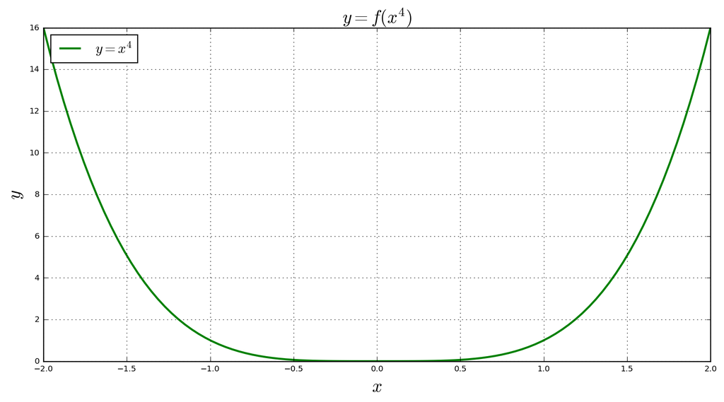

```python
fig, ax = plt.subplots(figsize=(12,6), dpi=180)
matplotlib.rcParams.update({'font.size': 8, 'font.family': 'serif'})
ax.grid(True)


ax.plot(x, x**4, 'g', label=r"$ y = x^4 $", linewidth=2)
ax.legend(loc=2, fontsize=14);  # upper left corner
ax.set_xlabel(r'$x$', fontsize=18)
ax.set_ylabel(r'$y$', fontsize=18)
ax.set_title('$y = f(x^4)$', fontsize=18);
```

## Subplots

Plot in the same figure two subplots one above each other:

- The absolute value
- The angle Of the following function:

Y = 1/(1+j*w)  
If w takes values between -10 and 10 in 500 steps.

- Label the plots.

```python
x = np.arange(-10, 10, 20/500)
y = 1/(1+x)
```

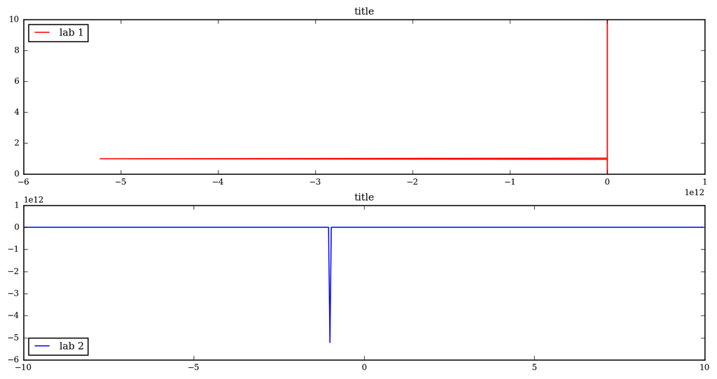

```python
fig, axes = plt.subplots(2, 1, figsize=(12,6), dpi=180)

matplotlib.rcParams.update({'font.size': 8, 'font.family': 'serif'})

axes[0].plot(y, abs(x), 'r', label="lab 1")
axes[1].plot(x,y, 'b', label="lab 2")

axes[0].set_title('title');
axes[1].set_title('title');

axes[0].legend(loc=2);  # upper left corner
axes[1].legend(loc=3);  # upper left corner
```

## Multiple plots

Plot the functions sin(t) and cos(t) at the same plot and put a legend.

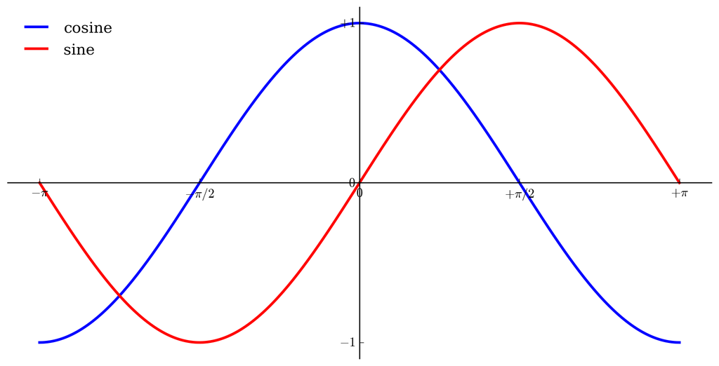

```python
fig, axes = plt.subplots(figsize=(12,6), dpi=180)
matplotlib.rcParams.update({'font.size': 12, 'font.family': 'serif'})

t = np.linspace(-np.pi, np.pi, 256, endpoint=True)
C,S = np.cos(t), np.sin(t)


plt.xlim(t.min()*1.1, t.max()*1.1)
plt.ylim(C.min()*1.1, C.max()*1.1)

ax = plt.gca()
ax.spines['right'].set_color('none')
ax.spines['top'].set_color('none')
ax.xaxis.set_ticks_position('bottom')
ax.spines['bottom'].set_position(('data',0))
ax.yaxis.set_ticks_position('left')
ax.spines['left'].set_position(('data',0))

plt.xticks([-np.pi, -np.pi/2, 0, np.pi/2, np.pi],
       [r'$-\pi$', r'$-\pi/2$', r'$0$', r'$+\pi/2$', r'$+\pi$'])

plt.yticks([-1, 0, +1],
       [r'$-1$', r'$0$', r'$+1$'])


plt.plot(t, C, color="blue", linewidth=2.5, linestyle="-", label="cosine")
plt.plot(t, S, color="red",  linewidth=2.5, linestyle="-", label="sine")



plt.legend(loc='upper left', frameon=False)




plt.show()
```